# Statistics of Small Scale Fisheries in Japan

Keita Abe

2020-09-22

# Introduction

This file shows the statistics of Japanese fisheries related to small scale fisheries (SSF). There is no clear definition of SSF in Japanese fisheries, but we refer coastal fisheries sector to SSF. In Japan, fisheries sectors are categolized into three: coastal (**Engan**), offshore (**Okiai**) and distant water (**Enyo**). The categolization depends on the type of fishing rights and permission, and offshore and distant water fisheries tends to use large industrialized vessels.

# Prefecture level data

## Geographical distribution of fishers

**Source**

```r
# search Fisheries Census data using estataapi package.
# Maybe easier to search on this web page
# https://www.e-stat.go.jp/stat-search/files?page=1&layout=datalist&toukei=00500210&tstat=000001033844&cycle=0&tclass1=000001036520&tclass2=000001036521&tclass3=000001036858
# Fisheries Census consists of 10 (9 + English version) sections (巻).
# 1~4 are about Marine fisheries, and each section corresponds to the level of geographical segmentation.
# 1 is national, 2 is prefectural
# 3 is at city/town level. 4 is even finer, fisheries district level.
# 7 is about processing/distributing sector at national, prefectural, and city level.
# 8 is about processing/distributing sector at fisheries district level.

##cat_census2 <- estat_getStatsList(appId = appID, searchWord = "漁業センサス第2巻 AND 就業者数") #都道府県別
##cat_census3 <- estat_getStatsList(appId = appID, searchWord = "漁業センサス第3巻") #市町区村別
##cat_census4 <- estat_getStatsList(appId = appID, searchWord = "漁業センサス第4巻") #市町区村別
##cat_census8 <- estat_getStatsList(appId = appID, searchWord = "漁業センサス第8巻") # 加工流通業
##cat_kowan <- estat_getStatsList(appId = appID, searchWord = "漁港港勢調査")

# meta info of the data of fishers
##estat_getMetaInfo(appId = appID, statsDataId = "0003117408")


# obtain the data # 都道府県別漁業者数2008
df_fishers_pref_2008 = estat_getStatsData(appId = appID,
                                statsDataId = "0003117227")

df_fishers_pref_age_2003 = estat_getStatsData(appId = appID,
                                              statsDataId = "0003261221") %>%
  mutate(year = 2003)

df_fishers_pref_age_2008 = estat_getStatsData(appId = appID,
                                     statsDataId = "0003123532")%>%
  mutate(year = 2008)

df_fishers_pref_age_2013 = estat_getStatsData(appId = appID,
                                              statsDataId = "0003122869") %>%
  mutate(year = 2013)


# api is not available yet
# obtain the excel file from the e-stat website
##download.file("https://www.e-stat.go.jp/stat-search/file-download?statInfId=000031918078&fileKind=0",
 ##                    "fishers_pref_2018.xls")
##df_fishers_pref_age_2018 = read_excel("fishers_pref_2018.xls")

# 2018 Census data downloaded and cleaned by Raphael Roman
df_fishers_pref_age_2018 = read_csv("Fishery_workers_2018.csv") %>%
  mutate(year = 2018)

  # load TODOFUKEN list
  todofuken <- read_tsv("todouhuken.txt", col_names = FALSE) %>%
    set_names(c("num","pref_JP","pref_EN")) %>%
    mutate(pref_EN = str_to_title(pref_EN)) %>%
    dplyr::select(-num)

  df_fishers_pref_age_2018 <- df_fishers_pref_age_2018 %>%
    left_join(todofuken, by = c("Prefectures" = "pref_EN")) %>%
    rename("pref_EN" = "Prefectures") %>%
    # for now, only use total number
    dplyr::select(year,pref_JP,Total) %>%
    rename("value" = "Total") %>%
    filter(!is.na(pref_JP))


df_fishers_pref = bind_rows(df_fishers_pref_age_2003,df_fishers_pref_age_2008,df_fishers_pref_age_2013) %>%
  mutate(area_code_num = as.numeric(area_code)/1000) %>% # make numeric to filter
  filter(area_code_num %in% c(1:47)) %>%
  mutate(cat03_code = ifelse(is.na(cat03_code),11,cat03_code),
         `自営漁業・漁業雇われ`=ifelse(is.na(`自営漁業・漁業雇われ`),"計",`自営漁業・漁業雇われ`))

# extract only aggregated (total) data (without gender/work type decompositions)
df_fishers_pref_agg = df_fishers_pref %>%
  filter(cat01_code == 11 & cat02_code == 11 & cat03_code == 11) %>%
  dplyr::select(year,area_code,area_code_num,`地域事項(全国・都道府県・大海区)`,value) %>%
  rename("pref_JP" = "地域事項(全国・都道府県・大海区)") %>%
  bind_rows(df_fishers_pref_age_2018) %>%
  left_join(todofuken, by = c("pref_JP"))

# combine with map data
map_fishers_pref_agg = jp_sh2 %>%
  left_join(df_fishers_pref_agg, by = c("NL_NAME_1" = "pref_JP")) %>%
  st_as_sf(.)
```

### Map with Hokkaido

**Source**

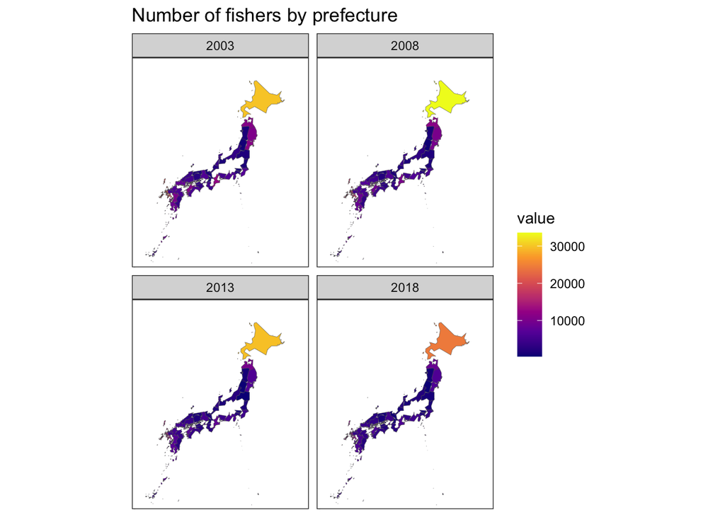

```r
# With Hokkaido (too large relative to others)
map_fun0 = function(){
  ggplot(map_fishers_pref_agg %>% filter(!is.na(year)), aes(fill = value)) +
    geom_sf(size = 0.1) +
    coord_sf(xlim = c(126,148), ylim = c(26,47), # set range, include Okinawa, but not other islands
             datum = NA) + # not show the coordinates and axis labels
    scale_fill_viridis_c(option = "plasma") +
    labs(title = "Number of fishers by prefecture") +
    theme_bw() +
    facet_wrap(~year, nrow = 2)
}
map_fun0()
```

### Without Hokkaido

Hokkaido is large as a map and the number of fishers.

**Source**

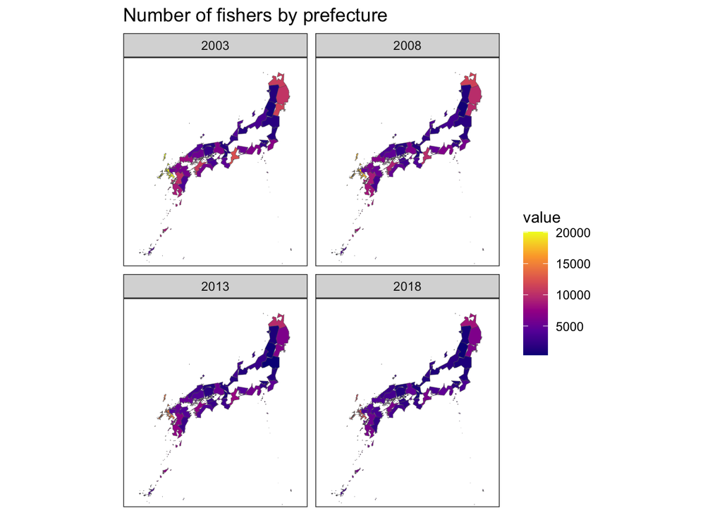

```r
# Remove Hokkaido (too large relative to others)
map_fun1 = function(){
ggplot(map_fishers_pref_agg %>% filter(NAME_1 != "Hokkaido") %>% filter(!is.na(year)), aes(fill = value)) +
  geom_sf(size = 0.1) +
  coord_sf(xlim = c(126,143), ylim = c(26,42), # set range, include Okinawa, but not other islands
           datum = NA) + # not show the coordinates and axis labels
  scale_fill_viridis_c(option = "plasma") +
  labs(title = "Number of fishers by prefecture") +
  theme_bw() +
  facet_wrap(~year, nrow = 2)
}
map_fun1()
```

### Extracting only 2013

**Source**

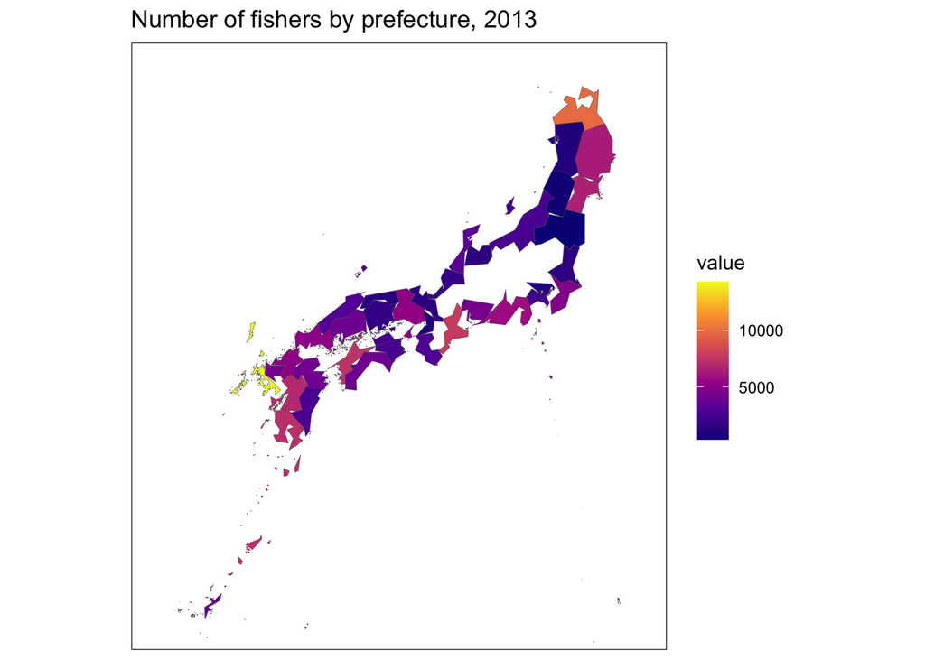

```r
# 2013 only
map_fun2013 = function(){
  ggplot(map_fishers_pref_agg %>% filter(area_code != "01000") %>% filter(year == 2013), aes(fill = value)) +
    geom_sf(size = 0.1) +
    coord_sf(xlim = c(126,143), ylim = c(26,42), # set range, include Okinawa, but not other islands
             datum = NA) + # not show the coordinates and axis labels
    scale_fill_viridis_c(option = "plasma") +
    labs(title = "Number of fishers by prefecture, 2013") +
    theme_bw()
}
map_fun2013()
```

### Time series

**Source**

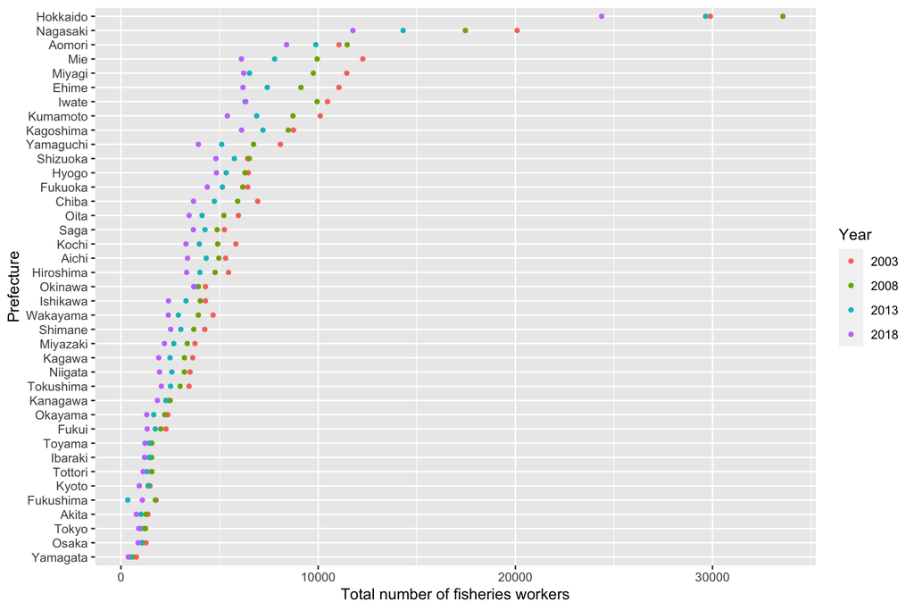

```r
plot_ts_fishers_pref = function(lang = "EN", save = FALSE){

    plot_EN = ggplot(df_fishers_pref_agg, aes(x = value, y = reorder(pref_EN,value), col = factor(year))) +
    geom_point(size = 1.15) +
    labs(x = "Total number of fisheries workers",y = "Prefecture", col = "Year")

    plot_JP = ggplot(df_fishers_pref_agg, aes(x = value, y = reorder(pref_JP,value), col = factor(year))) +
    geom_point(size = 1.5) +
    labs(x = "漁業従事者数(合計)",y = "都道府県", col = "年(漁業センサス)") +
      theme(legend.position = "bottom",
            text = element_text(family = "HiraKakuPro-W3"))

  if(lang == "JP"){
    print(plot_JP)
  }else{
    print(plot_EN)
  }

  if(save == TRUE){
    ggsave(paste("Total_number_of_fisheries_workers_prefecture_",lang,".png"),height = 9,width = 6)
  }



}

 plot_ts_fishers_pref()
```

## Prefecture level analysis by ages

**Source**

```r
#### By ages #####

### prefecture level ###
df_fishers_pref_age = df_fishers_pref %>%
  filter(cat01_code != 11 & cat02_code == 11 & cat03_code == 11) %>%
  dplyr::select(-cat01_code, -cat02_code,-cat03_code) %>% # only 2008 or 2013
  mutate(`年齢階層_15歳-75歳以上` = parse_number(`年齢階層_15歳-75歳以上`)) %>%
  mutate(`年齢階層_15歳-75歳以上` = paste0("age_",`年齢階層_15歳-75歳以上`)) %>%
  pivot_wider(names_from = "年齢階層_15歳-75歳以上", values_from = "value") %>%
  mutate(total = rowSums(select(., starts_with("age"))),
         older = age_65 + age_70 + age_75,
         fisher_aging_rate = older/total)

# combine with map data
map_fishers_pref_age = jp_sh2 %>%
  left_join(df_fishers_pref_age, by = c("NL_NAME_1" = "地域事項(全国・都道府県・大海区)")) %>%
  st_as_sf(.)
```

### With Hokkaido

**Source**

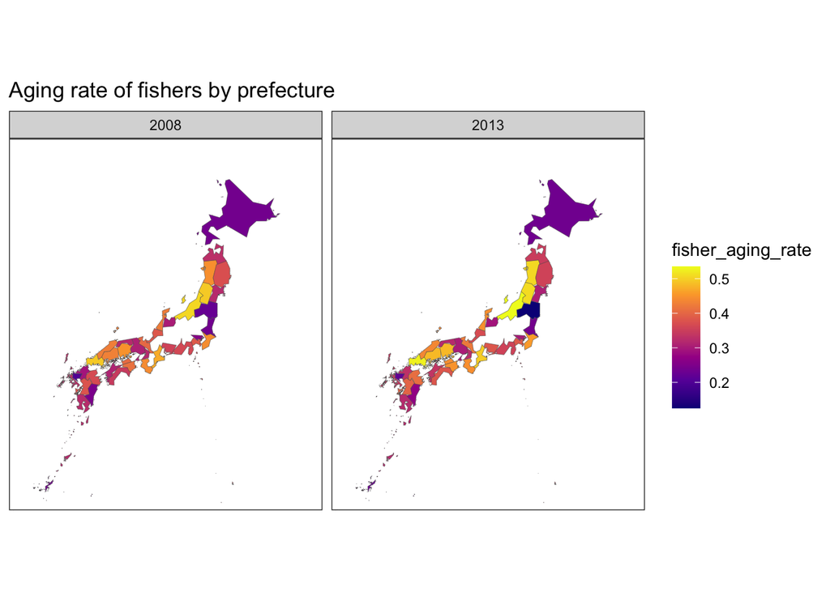

```r
# With Hokkaido (too large relative to others)
map_age_fun0 = function(){
  ggplot(map_fishers_pref_age %>% filter(!is.na(year)), aes(fill = fisher_aging_rate)) +
    geom_sf(size = 0.1) +
    coord_sf(xlim = c(126,148), ylim = c(26,47), # set range, include Okinawa, but not other islands
             datum = NA) + # not show the coordinates and axis labels
    scale_fill_viridis_c(option = "plasma") +
    labs(title = "Aging rate of fishers by prefecture") +
    theme_bw() +
    facet_wrap(~year)
}
map_age_fun0()
```

# Town level data

**Source**

```r
# town level
df_fishers_town_age_2008 = estat_getStatsData(appId = appID,
                                              statsDataId = "0003124203") %>%
  mutate(year = 2008)

df_fishers_town_age_2013 = estat_getStatsData(appId = appID,
                                              statsDataId = "0003124202") %>%
  mutate(year = 2013)

df_fishers_town = bind_rows(df_fishers_town_age_2008,df_fishers_town_age_2013) %>%
  mutate(area_code_num = as.numeric(area_code)/1000) # make numeric to filter

## Town level age data
df_fishers_town_age = df_fishers_town %>%
  mutate(town = ifelse(year == 2008, `地域事項(市区町村（漁業地区))_2008`,`地域事項(市区町村(漁業地区)）_2013`)) %>%
  filter(cat01_code != 11 & cat02_code == 11) %>%
  dplyr::select(-cat01_code, -cat02_code) %>% # only 2008 or 2013
  mutate(`年齢階層_15歳-75歳以上` = parse_number(`年齢階層_15歳-75歳以上`)) %>%
  mutate(`年齢階層_15歳-75歳以上` = paste0("age_",`年齢階層_15歳-75歳以上`)) %>%
  pivot_wider(names_from = "年齢階層_15歳-75歳以上", values_from = "value") %>%
  mutate_at(vars(starts_with("age_")), list(~ifelse(is.na(.),0,.))) %>%
  mutate(total = rowSums(select(., starts_with("age"))),
         older = age_65 + age_70 + age_75,
         fisher_aging_rate = older/total)
```

## Town level General Population data

Download and clearning data of general population by age-town from 2015 census

**Source**

```r
# ====== general population ==============

# obtain the excel file from the e-stat website
#download.file("https://www.e-stat.go.jp/stat-search/file-download?statInfId=000031594311&fileKind=0",
#              "pop_town_2015.xls")
df_pop_town_age_2015 = read_excel("pop_town_2015.xls")

# extract column names
colname_pop_town_age_2015 = df_pop_town_age_2015 %>% slice(6)

# remove headers
df_pop_town_age_2015 <- df_pop_town_age_2015 %>%
  slice(-c(1:10))

# replace column names
colnames(df_pop_town_age_2015) <- colname_pop_town_age_2015
##class(df_pop_town_age_2015)
# convert to numeric
df_pop_town_age_2015 <- type_convert(df_pop_town_age_2015, na = c("","NA","-"," - "))

# remove prefecture and district (ward) within large cities
df_pop_town_age_2015 <- df_pop_town_age_2015 %>%
  filter(`市などの別` != "a" & `市などの別` != "0")
```

Check data

**Source**

```r
## skim(df_pop_town_age_2015)
```

**Source**

```r
# merge fisheries census data

df_pop_town_age_2015_fish <- df_pop_town_age_2015 %>%
  left_join(df_fishers_town_age %>% filter(year == 2013), by = c("都道府県・市区町村名" = "town")) %>%
  mutate(fish_town = ifelse(!is.na(total), "Yes", "No"))
```

**Source**

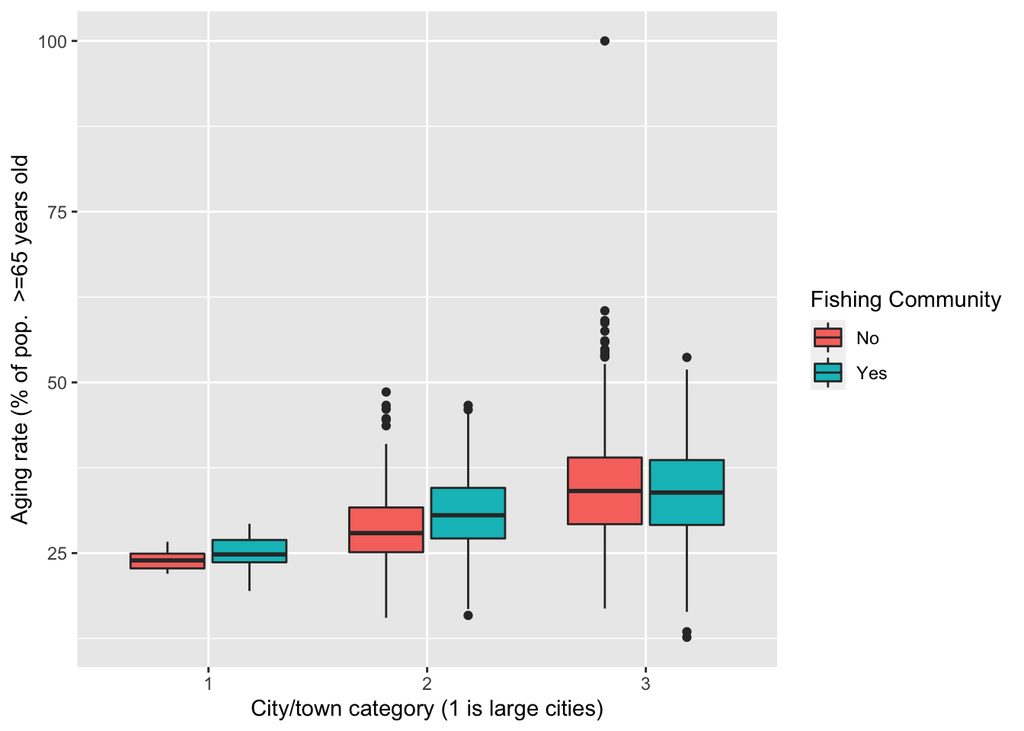

```r
ggplot(df_pop_town_age_2015_fish, aes(x = `市などの別`, fill=as.factor(fish_town), y=`【年齢別割合（総数）】65歳以上人口(％)`)) +
         geom_boxplot() +
  labs(x = "City/town category (1 is large cities)",fill = "Fishing Community", y = "Aging rate (% of pop.  >=65 years old")
```

## Fishery type by town

Download and cleaning Fishery type by town from 2013 Fishery Census.

**Source**

```r
# obtain the excel file from the e-stat website
download.file("https://www.e-stat.go.jp/stat-search/file-download?statInfId=000029149689&fileKind=0",
              "entity_town_2013.xls")
df_fish_entity_town_2013 = read_excel("entity_town_2013.xls")

# extract header
header_fish_entity_town_2013 <- df_fish_entity_town_2013 %>% slice(c(1:10)) %>%
  tidyr::fill(.,.direction = "down")

# make new header
colname_fish_entity_town_2013 = c("pref","district","town","nothing","num",
                                  "total_entity","no_ves","ves_no_eng","ves_out_eng","ves_1t",
                                  "ves_1_3","ves_3_5","ves_5_10","ves_10_20","ves_20_30",
                                  "ves_30_50","ves_50_100","ves_100_200","ves_200_500","ves_500_1000",
                                  "ves_1000_3000","ves_3000","setnet_big","setnet_salm","setnet_sma",
                                  "aqa_salm","aqa_yt","aqa_snap","aqa_flou","aqa_tuna","aqa_oth_fish",
                                  "aqa_scal","aqa_oys","aqa_oth_shell","aqa_shri","aqa_hoya",
                                  "aqa_oth_anim","aqa_konbu","aqa_wakame","aqa_nori","aqa_oth_weed",
                                  "aqa_pearl","aqa_peashell","coast_ent_total","coast_ent_aqa",
                                  "coast_ent_oth","middle_ent","large_ent")

# remove header
df_fish_entity_town_2013 <- df_fish_entity_town_2013 %>% slice(-c(1:10))

# new colnames
colnames(df_fish_entity_town_2013) <- colname_fish_entity_town_2013

# convert - to 0
df_fish_entity_town_2013 <- df_fish_entity_town_2013 %>%
  mutate_all(list(~ifelse(. == "-",0,.))) %>%
  mutate_at(vars(6:48), list(~as.numeric(.))) # NA is generated, because some towns do not have specific breakdown of the entities, which was "x" originally.


# --- merge to df_pop_town_age_2015_fish ----

df_pop_town_age_2015_fish_entity <- df_pop_town_age_2015_fish %>%
  left_join(df_fish_entity_town_2013, by = c("都道府県・市区町村名" = "town")) %>%
  mutate(coast_ent_per_capita =coast_ent_total/`【年齢（総数）】総数人口(人)`)
```

### Aging rate and ratio of coastal fisheries

**Source**

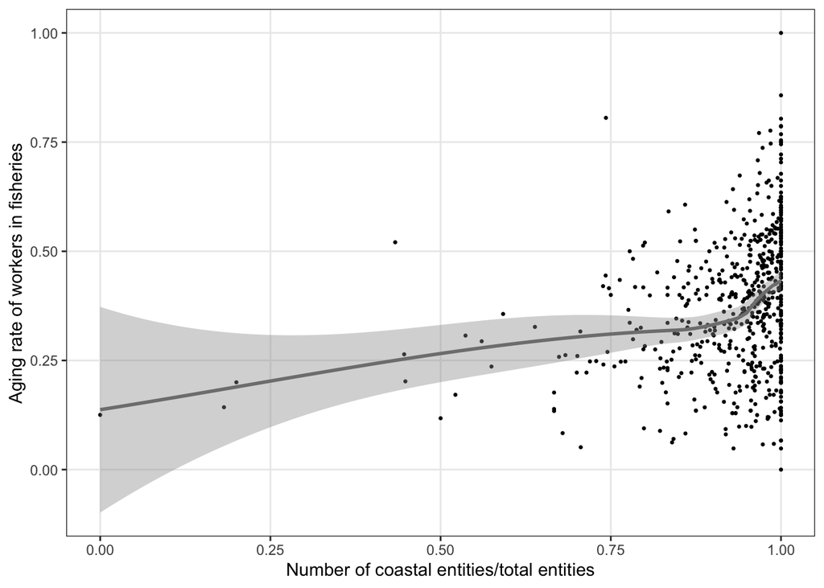

```r
# --- plot aging vs small scale entity

ggplot(df_pop_town_age_2015_fish_entity %>% filter(fish_town == "Yes"),
       aes(x = coast_ent_total/total_entity, y = fisher_aging_rate)) +
  geom_point(size = 0.5) +
  geom_smooth(method = c("loess"), col = "grey50") +
  labs(x = "Number of coastal entities/total entities", y= "Aging rate of workers in fisheries") +
  theme_bw() +
  theme(panel.grid.minor = element_blank())
```

### Aging rate and ratio of coastal fisheries without aquaculture

There are many small scale aquaculture along the coast. Not all of them are as industrialized as other countries like Norway, but we exclude them from the coastal fisheries. Here we show the number of entities of coastal capture fisheries relative to the total number of entities.

**Source**

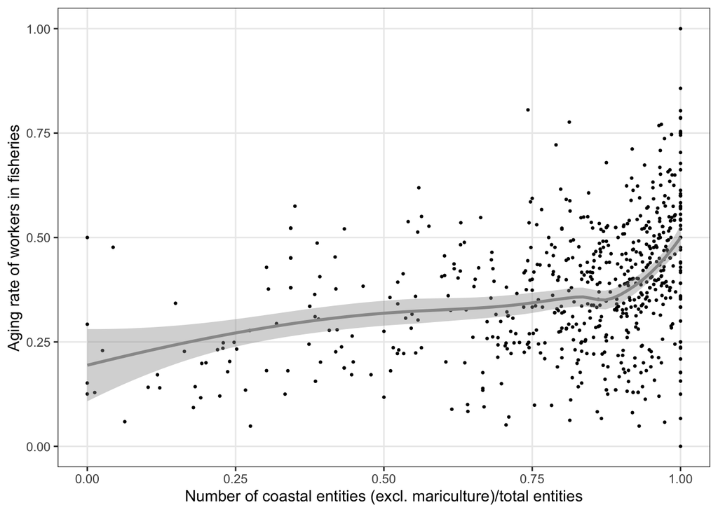

```r
ggplot(df_pop_town_age_2015_fish_entity %>% filter(fish_town == "Yes"),
       aes(x = coast_ent_oth/total_entity, y = fisher_aging_rate)) +
  geom_point(size = 0.5) +
  geom_smooth(method = c("loess"), col = "grey60") +
  labs(x = "Number of coastal entities (excl. mariculture)/total entities",y = "Aging rate of workers in fisheries") +
  theme_bw() +
  theme(panel.grid.minor = element_blank())
```

### Aging rate of general population and SSF ratio

**Source**

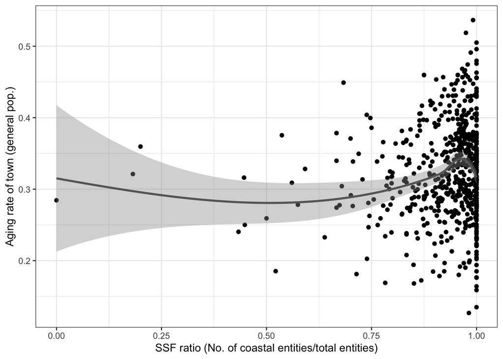

```r
ggplot(df_pop_town_age_2015_fish_entity %>% filter(fish_town == "Yes"),
       aes(x = coast_ent_total/total_entity, y = `【年齢別割合（総数）】65歳以上人口(％)`/100)) +
  geom_point() +
  geom_smooth(method = c("loess"), col = "grey40") +
  labs(x = "SSF ratio (No. of coastal entities/total entities)", y = "Aging rate of town (general pop.)") +
  theme_bw()
```

### Aging rate of general population and SSF ratio

Again, excluding the aquaculture.

**Source**

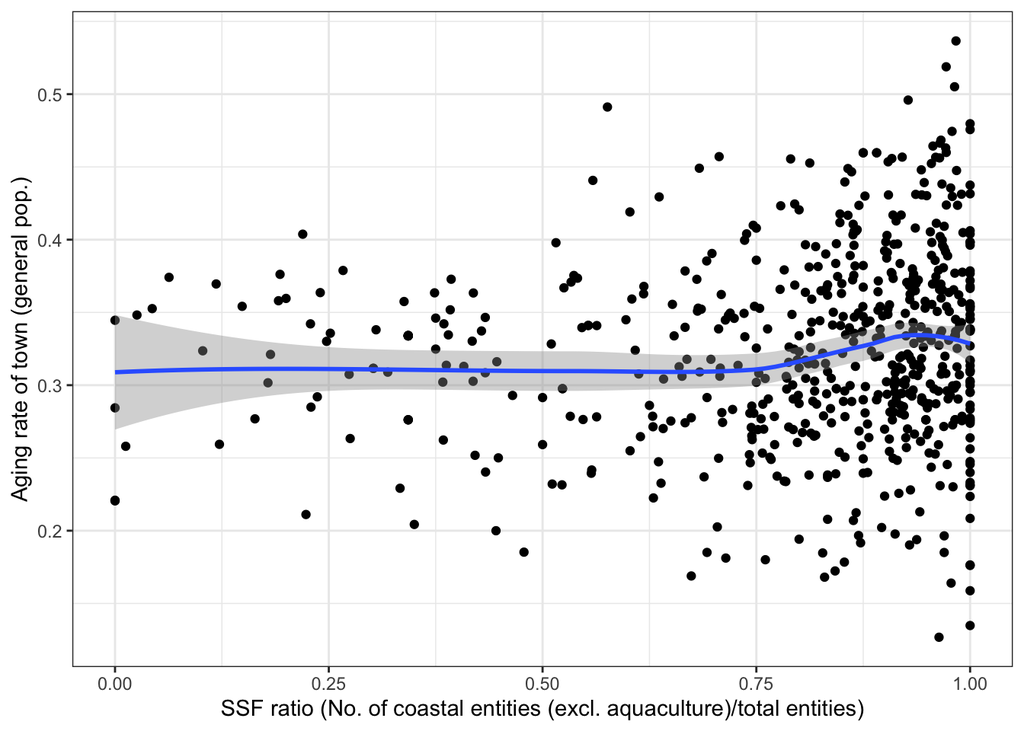

```r
ggplot(df_pop_town_age_2015_fish_entity %>% filter(fish_town == "Yes"),
       aes(x = coast_ent_oth/total_entity, y = `【年齢別割合（総数）】65歳以上人口(％)`/100)) +
  geom_point() +
  geom_smooth(method = c("loess")) +
  labs(x = "SSF ratio (No. of coastal entities (excl. aquaculture)/total entities)", y = "Aging rate of town (general pop.)") +
  theme_bw()
```

# Workers, by gender

**Source**

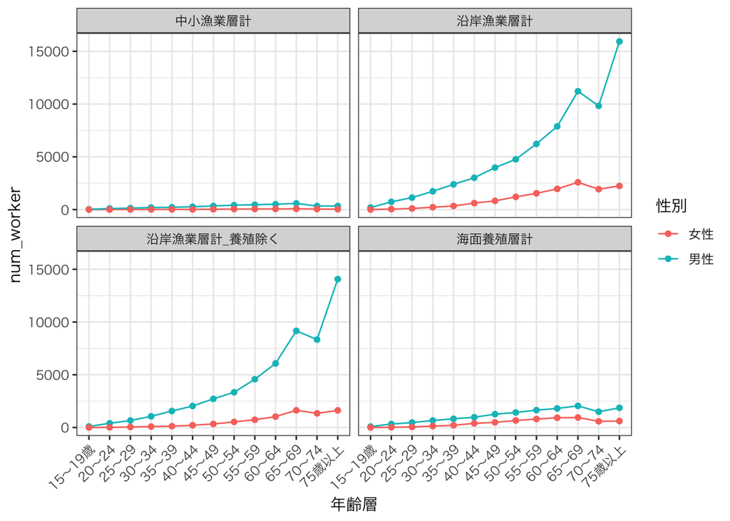

```r
dat_work_gender = readxl::read_excel("j117-30-121.xls",sheet = 2) %>%
  pivot_longer(cols = c(-`年齢層`,-`性別`), names_to = "fisheries", values_to = "num_worker") %>%
  mutate(`性別`= ifelse(`性別` == "男", "男性","女性"))

ggplot(dat_work_gender, aes(x = `年齢層`, y = num_worker, col = `性別`, group = `性別`)) +
  geom_line() +
  geom_point() +
  facet_wrap(~fisheries) +
  theme_bw(base_family="HiraKakuPro-W3") +
  theme(axis.text.x = element_text(angle = 45,hjust = 1))
```

**Source**

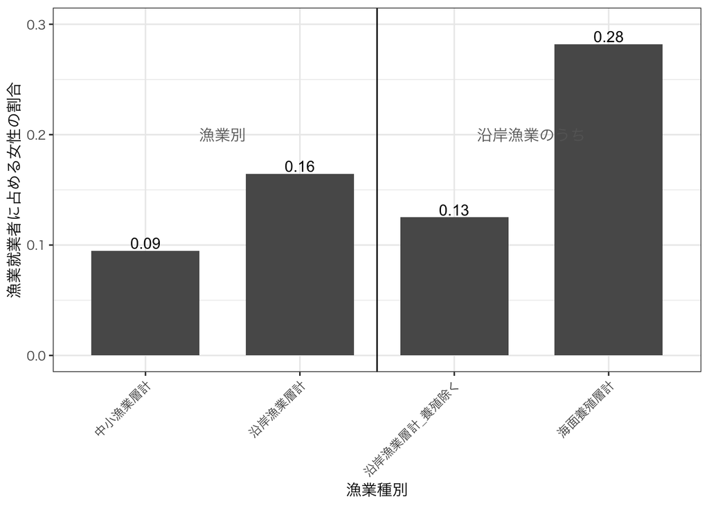

```r
# ratio of gender (aggregated)

dat_work_gender_agg <- dat_work_gender %>%
  group_by(`性別`,fisheries) %>%
  summarise(num_worker = sum(num_worker)) %>%
  ungroup()

dat_work_gender_agg_ratio <- dat_work_gender_agg %>%
  group_by(fisheries) %>%
  mutate(gender_ratio = num_worker/sum(num_worker)) %>%
  ungroup() %>%
  mutate(large_category = ifelse(fisheries %in% c("沿岸漁業層計_養殖除く","海面養殖層計"), "沿岸漁業層のうち","漁業層別"),
         large_category_n = as.numeric(large_category))



# plot

# for the vertical line
myLoc <-
  (which(levels(as.factor(dat_work_gender_agg_ratio$fisheries)) == "沿岸漁業層計") +
     which(levels(as.factor(dat_work_gender_agg_ratio$fisheries)) == "沿岸漁業層計_養殖除く"))/2


ggplot(dat_work_gender_agg_ratio %>% filter(`性別`=="女性"), aes(x = fisheries, y = gender_ratio)) +
  geom_bar(stat = "identity", width = 0.7) +
  #geom_point(size = 2) +
  geom_vline(xintercept = myLoc) +
  scale_x_discrete(drop = FALSE) +
  geom_text(aes(label=round(gender_ratio,2)),hjust=0.5, vjust=-0.2) +
  ylim(0,0.3) +
  annotate(geom="text", x=1.5, y=0.2, label="漁業別",
              color="grey40",family="HiraKakuPro-W3") +
  annotate(geom="text", x=3.5, y=0.2, label="沿岸漁業のうち",
              color="grey40",family="HiraKakuPro-W3") +
  labs(y = "漁業就業者に占める女性の割合", x="漁業種別") +
  theme_bw(base_family="HiraKakuPro-W3") +
  theme(axis.text.x = element_text(angle = 45,hjust = 1))
```

# Accident statistics

download and cleaning the accident statistics from Coast Guard website. I manually copied the data and compiled the source file. (Because their excel format is not well suited for imporating as data frame.)

Small vessels tends to have accidents.

**Source**

```r
dat_acci = read_xlsx("accidents_by_boat_size_2015_2019.xlsx") %>%
  pivot_longer(cols = -tons, names_to = "year",values_to = "number") %>%
  mutate(tons2 = ifelse(tons %in% c("500-1000t","1000-3000t",">3000t"),
                        ">500t",tons),
         tons3 = ifelse(tons %in% c("100-500t","500-1000t","1000-3000t",">3000t"),
                        ">100t",tons)) %>%
  mutate(tons = factor(tons, levels = c("<5t","5-20t","20-100t","100-500t","500-1000t","1000-3000t",">3000t")),
         tons2 = factor(tons2, levels =
                          c("<5t","5-20t","20-100t","100-500t",">500t")),
         tons3 = factor(tons3, levels =
                          c("<5t","5-20t","20-100t",">100t")))

## ggsave("accident_fishery_2015-2019.png", plot_acci)
```

**Source**

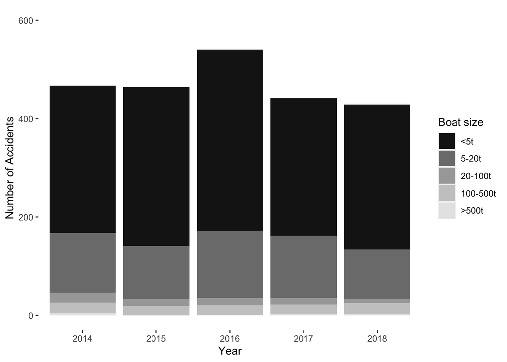

```r
plot_acci2 = ggplot(dat_acci, aes(x = year, y = number, fill = tons2, order = tons2)) +
  geom_bar(position = "stack",stat = "identity") +
  ylim(0,600) +
  #scale_fill_viridis_d("Boat size",
  scale_fill_grey("Boat size",
                  start = 0.1,
                  end = 0.9,
                    breaks= c("<5t","5-20t","20-100t","100-500t",">500t"),
                    labels= c("<5t","5-20t","20-100t","100-500t",">500t")) +
  labs(x = "Year", y = "Number of Accidents") +
  theme(panel.grid.major = element_blank(),
        panel.grid.minor = element_blank(),
        panel.background = element_blank())

plot_acci2
```

**Source**

```r
## ggsave("accident_fishery_2015-2019_500t_grey.png", plot_acci2, width = 4, height = 3, units = "in")
```

**Source**

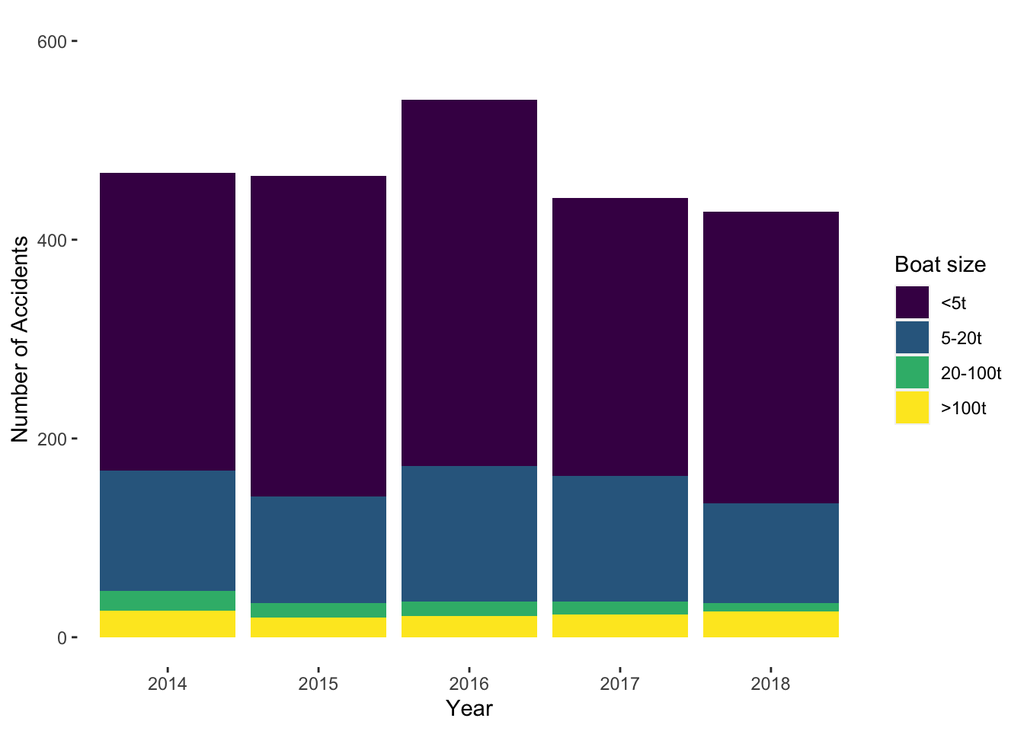

```r
plot_acci3 = ggplot(dat_acci, aes(x = year, y = number, fill = tons3, order = tons3)) +
  geom_bar(position = "stack",stat = "identity") +
  ylim(0,600) +
  scale_fill_viridis_d("Boat size",
                    breaks= c("<5t","5-20t","20-100t",">100t"),
                    labels= c("<5t","5-20t","20-100t",">100t")) +
  labs(x = "Year", y = "Number of Accidents") +
  theme(panel.grid.major = element_blank(),
        panel.grid.minor = element_blank(),
        panel.background = element_blank())

plot_acci3
```

**Source**

```r
## ggsave("accident_fishery_2015-2019_100t.png", plot_acci3)
```